# Mini-Project 04 - Just the Fact(-Check)s, Ma’am!

## Task 3

I explore the CES data using both summary statistics and visualizations. After joining the tables, I calculate key measures of revision size and patterns over the past 45 years and create several plots to show trends, extremes, and any seasonal differences in the revisions.

```r
# Join the two datasets
ces_combined <- ces_final |>
  left_join(revisions_final, by = "date") |>
  mutate(
    # Calculate the change in employment from previous month
    level_change = level - lag(level),
    # Calculate revision as percentage of final level
    revision_pct = (revision / final) * 100,
    # Calculate absolute revision percentage
    abs_revision_pct = abs(revision_pct),
    # Add year and month for grouping
    year = year(date),
    month = month(date, label = TRUE),
    # Add decade
    decade = floor(year / 10) * 10
  )
```

```r
library(knitr)
library(kableExtra)

# Statistic 1 & 2: Largest positive and negative revisions
extreme_revisions <- ces_combined |>
  filter(!is.na(revision)) |>
  arrange(desc(revision)) |>
  slice(c(1, n())) |>
  select(Date = date, `Revision (thousands)` = revision, `Employment Level` = level) |>
  mutate(Type = c("Largest Positive", "Largest Negative"))

extreme_revisions |>
  kable(caption = "Largest Positive and Negative Revisions",
        digits = 0,
        format.args = list(big.mark = ",")) |>
  kable_styling(bootstrap_options = c("striped", "hover", "condensed"),
                full_width = FALSE,
                position = "left") |>
  row_spec(0, bold = TRUE, color = "white", background = "#800080")
```

Largest Positive and Negative Revisions

| Date | Revision (thousands) | Employment Level | Type |
| --- | --- | --- | --- |
| 1993-01-01 | 69 | 109,790 | Largest Positive |
| 2009-01-01 | -86 | 134,078 | Largest Negative |

```r
# Statistic 3: Average absolute revision by decade
avg_revision_by_decade <- ces_combined |>
  filter(!is.na(revision)) |>
  group_by(Decade = decade) |>
  summarize(
    `Avg Absolute Revision` = mean(abs(revision), na.rm = TRUE),
    `Median Absolute Revision` = median(abs(revision), na.rm = TRUE),
    `Number of Months` = n()
  ) |>
  arrange(Decade)

avg_revision_by_decade |>
  kable(caption = "Average Absolute Revision by Decade",
        digits = 1) |>
  kable_styling(bootstrap_options = c("striped", "hover"),
                full_width = FALSE) |>
  row_spec(0, bold = TRUE, color = "white", background = "#4472C4") |>
  column_spec(1, bold = TRUE)
```

Average Absolute Revision by Decade

| Decade | Avg Absolute Revision | Median Absolute Revision | Number of Months |
| --- | --- | --- | --- |
| 1970 | 59.0 | 59.0 | 1 |
| 1980 | 34.0 | 32.5 | 10 |
| 1990 | 28.1 | 28.0 | 10 |
| 2000 | 35.2 | 17.5 | 10 |
| 2010 | 22.6 | 18.5 | 10 |
| 2020 | 37.0 | 29.5 | 6 |

```r
# Statistic 4: Fraction of positive vs negative revisions
revision_direction <- ces_combined |>
  filter(!is.na(revision)) |>
  summarize(
    `Total Revisions` = n(),
    `Positive` = sum(revision > 0, na.rm = TRUE),
    `Negative` = sum(revision < 0, na.rm = TRUE),
    `Zero` = sum(revision == 0, na.rm = TRUE),
    `% Positive` = (Positive / `Total Revisions`) * 100,
    `% Negative` = (Negative / `Total Revisions`) * 100
  )

revision_direction |>
  kable(caption = "Revision Direction Summary",
        digits = 1) |>
  kable_styling(bootstrap_options = c("striped", "hover"),
                full_width = FALSE) |>
  row_spec(0, bold = TRUE, color = "white", background = "#ED7D31")
```

Revision Direction Summary

| Total Revisions | Positive | Negative | Zero | % Positive | % Negative |
| --- | --- | --- | --- | --- | --- |
| 47 | 29 | 17 | 1 | 61.7 | 36.2 |

```r
# Statistic 6: Which months have largest revisions?
avg_revision_by_month <- ces_combined |>
  filter(!is.na(revision)) |>
  group_by(Month = month) |>
  summarize(
    `Avg Abs Revision` = mean(abs(revision), na.rm = TRUE),
    `Median Abs Revision` = median(abs(revision), na.rm = TRUE),
    `Count` = n()
  ) |>
  arrange(desc(`Avg Abs Revision`))

avg_revision_by_month |>
  kable(caption = "Average Absolute Revision by Month",
        digits = 1) |>
  kable_styling(bootstrap_options = c("striped", "hover"),
                full_width = FALSE) |>
  row_spec(0, bold = TRUE, color = "white", background = "#5B9BD5") |>
  row_spec(1, bold = TRUE, background = "white")  # Highlight top month
```

Average Absolute Revision by Month

| Month | Avg Abs Revision | Median Abs Revision | Count |
| --- | --- | --- | --- |
| Jan | 31.5 | 27 | 47 |

```r
# Statistic 7: Recent years summary
recent_revisions <- ces_combined |>
  filter(year >= 2020, !is.na(revision)) |>
  summarize(
    `Avg Revision` = mean(revision, na.rm = TRUE),
    `Avg Abs Revision` = mean(abs(revision), na.rm = TRUE),
    `Max Revision` = max(revision, na.rm = TRUE),
    `Min Revision` = min(revision, na.rm = TRUE),
    `% Positive` = sum(revision > 0) / n() * 100
  )

recent_revisions |>
  kable(caption = "Recent Years (2020-2025) Revision Summary",
        digits = 1) |>
  kable_styling(bootstrap_options = c("striped", "hover"),
                full_width = FALSE) |>
  row_spec(0, bold = TRUE, color = "white", background = "darkgreen")
```

Recent Years (2020-2025) Revision Summary

| Avg Revision | Avg Abs Revision | Max Revision | Min Revision | % Positive |
| --- | --- | --- | --- | --- |
| 2 | 37 | 67 | -59 | 50 |

## Data Visualizations

**Visualization #1:** This chart shows how the total number of jobs grew from about 89 million in 1979 to around 159 million in 2025. You can see big drops during some tough times, like the early 90s recession, the financial crisis in 2008, and the pandemic in 2020. After these drops, the jobs numbers bounced back pretty fast.

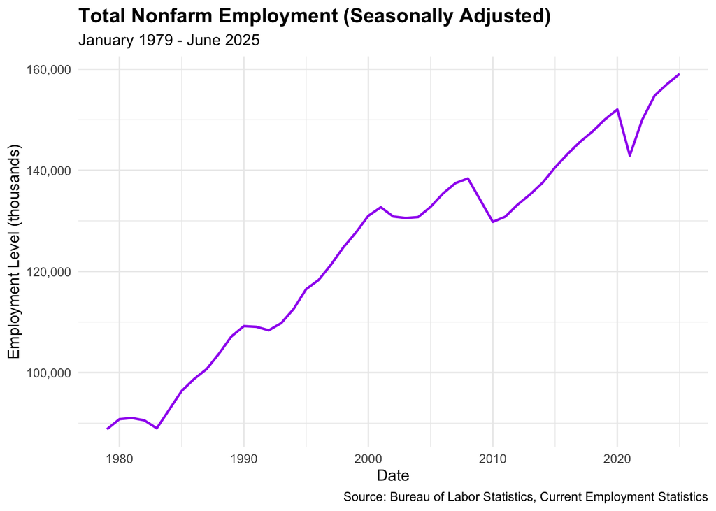

```r
library(ggplot2)

# Visualization 1: Employment level over time
ggplot(ces_combined, aes(x = date, y = level)) +
  geom_line(color = "purple", linewidth = 0.8) +
  scale_y_continuous(labels = scales::comma) +
  labs(
    title = "Total Nonfarm Employment (Seasonally Adjusted)",
    subtitle = "January 1979 - June 2025",
    x = "Date",
    y = "Employment Level (thousands)",
    caption = "Source: Bureau of Labor Statistics, Current Employment Statistics"
  ) +
  theme_minimal() +
  theme(
    plot.title = element_text(face = "bold", size = 14),
    plot.subtitle = element_text(size = 11),
    axis.title = element_text(size = 11)
  )
```

**Visualization #2:** Here, we can see how the employment numbers were updated after they were first reported. Some revisions went up (green) and some went down (red). The biggest changes happened during big economic problems, like 2008 and 2020. Overall, there is no clear pattern that the revisions are always going up or always going down.

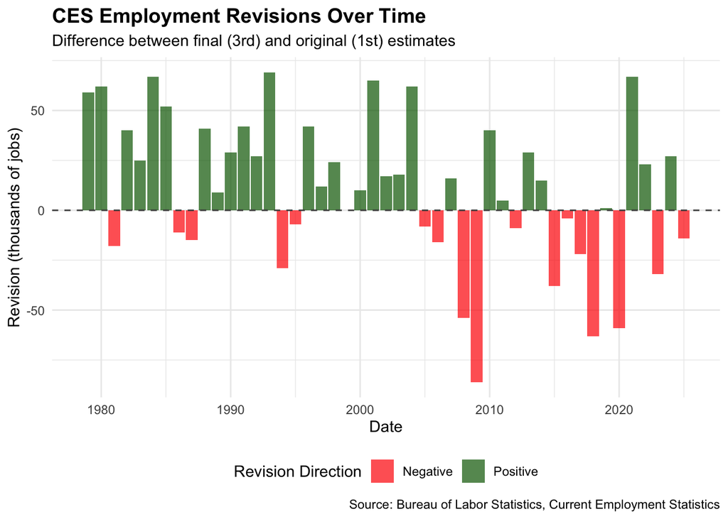

```r
# Visualization 2: Revisions over time
ggplot(ces_combined |> filter(!is.na(revision)),
       aes(x = date, y = revision)) +
  geom_col(aes(fill = revision > 0), alpha = 0.7) +
  geom_hline(yintercept = 0, linetype = "dashed", color = "gray30") +
  scale_fill_manual(
    values = c("TRUE" = "darkgreen", "FALSE" = "red"),
    labels = c("Negative", "Positive"),
    name = "Revision Direction"
  ) +
  labs(
    title = "CES Employment Revisions Over Time",
    subtitle = "Difference between final (3rd) and original (1st) estimates",
    x = "Date",
    y = "Revision (thousands of jobs)",
    caption = "Source: Bureau of Labor Statistics, Current Employment Statistics"
  ) +
  theme_minimal() +
  theme(
    plot.title = element_text(face = "bold", size = 14),
    plot.subtitle = element_text(size = 11),
    axis.title = element_text(size = 11),
    legend.position = "bottom"
  )
```

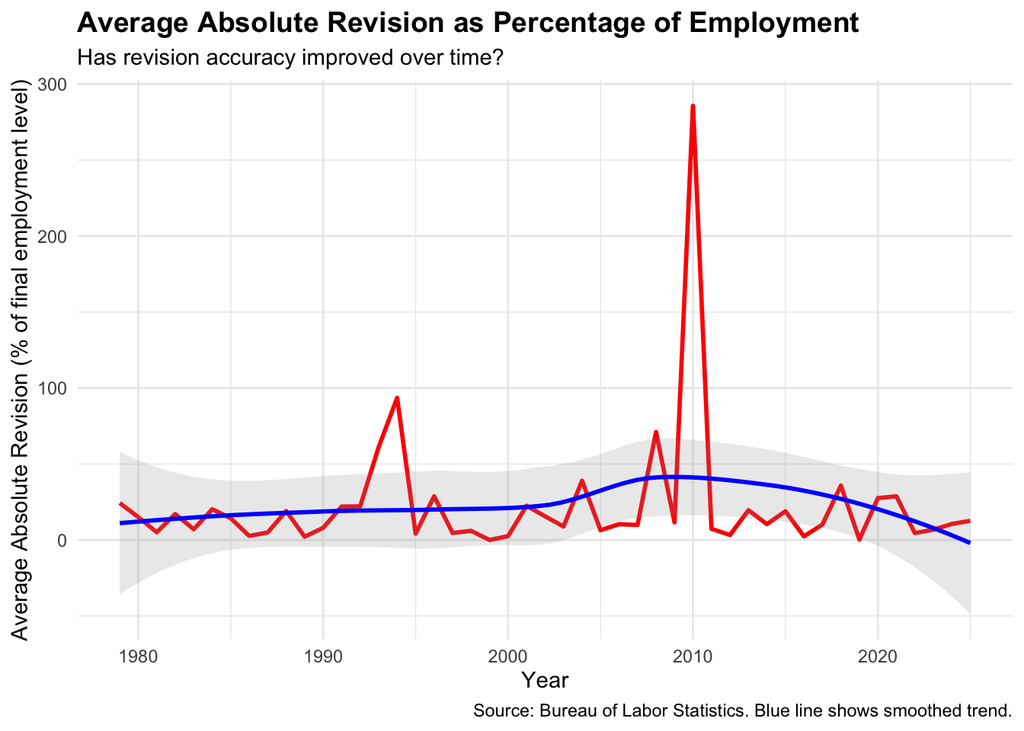

```r
# Create the data needed for this plot
avg_revision_pct_by_year <- ces_combined |>
  filter(!is.na(abs_revision_pct)) |>
  group_by(year) |>
  summarize(
    avg_abs_rev_pct = mean(abs_revision_pct, na.rm = TRUE),
    median_abs_rev_pct = median(abs_revision_pct, na.rm = TRUE)
  )

# Visualization 3: Absolute revision percentage over time
ggplot(avg_revision_pct_by_year |> filter(!is.na(avg_abs_rev_pct)),
       aes(x = year, y = avg_abs_rev_pct)) +
  geom_line(color = "red", linewidth = 1) +
  geom_smooth(method = "loess", se = TRUE, alpha = 0.2, color = "blue") +
  labs(
    title = "Average Absolute Revision as Percentage of Employment",
    subtitle = "Has revision accuracy improved over time?",
    x = "Year",
    y = "Average Absolute Revision (% of final employment level)",
    caption = "Source: Bureau of Labor Statistics. Blue line shows smoothed trend."
  ) +
  theme_minimal() +
  theme(
    plot.title = element_text(face = "bold", size = 14),
    plot.subtitle = element_text(size = 11),
    axis.title = element_text(size = 11)
  )
```

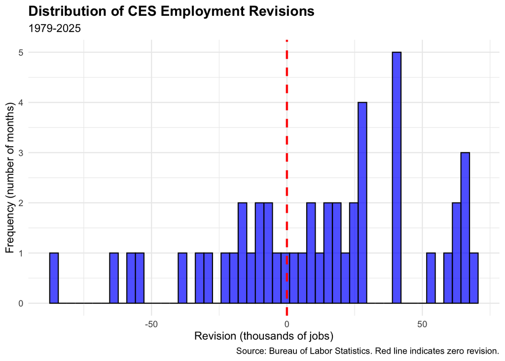

```r
# Visualization 4: Distribution of revisions
ggplot(ces_combined |> filter(!is.na(revision)),
       aes(x = revision)) +
  geom_histogram(bins = 50, fill = "blue", alpha = 0.7, color = "black") +
  geom_vline(xintercept = 0, linetype = "dashed", color = "red", size = 1) +
  labs(
    title = "Distribution of CES Employment Revisions",
    subtitle = "1979-2025",
    x = "Revision (thousands of jobs)",
    y = "Frequency (number of months)",
    caption = "Source: Bureau of Labor Statistics. Red line indicates zero revision."
  ) +
  theme_minimal() +
  theme(
    plot.title = element_text(face = "bold", size = 14),
    plot.subtitle = element_text(size = 11),
    axis.title = element_text(size = 11)
  )
```

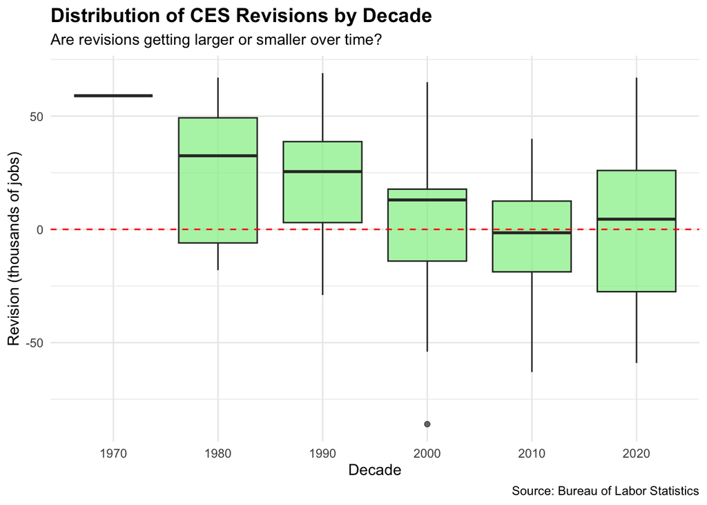

```r
# Visualization 5: Boxplot of revisions by decade
ggplot(ces_combined |> filter(!is.na(revision), !is.na(decade)),
       aes(x = factor(decade), y = revision)) +
  geom_boxplot(fill = "lightgreen", alpha = 0.7) +
  geom_hline(yintercept = 0, linetype = "dashed", color = "red") +
  labs(
    title = "Distribution of CES Revisions by Decade",
    subtitle = "Are revisions getting larger or smaller over time?",
    x = "Decade",
    y = "Revision (thousands of jobs)",
    caption = "Source: Bureau of Labor Statistics"
  ) +
  theme_minimal() +
  theme(
    plot.title = element_text(face = "bold", size = 14),
    plot.subtitle = element_text(size = 11),
    axis.title = element_text(size = 11)
  )
```

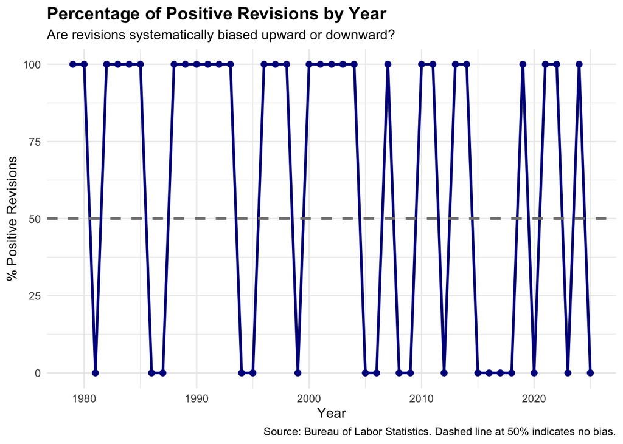

```r
# Create the data for this plot
revision_summary_by_year <- ces_combined |>
  filter(!is.na(revision)) |>
  group_by(year) |>
  summarize(
    pct_positive = sum(revision > 0) / n() * 100,
    pct_negative = sum(revision < 0) / n() * 100,
    count = n()
  )

# Visualization 6: Positive vs negative revisions over time
ggplot(revision_summary_by_year, aes(x = year, y = pct_positive)) +
  geom_line(color = "darkblue", linewidth = 1) +
  geom_point(color = "darkblue", size = 2) +
  geom_hline(yintercept = 50, linetype = "dashed", color = "gray50", linewidth = 1) +
  scale_y_continuous(limits = c(0, 100)) +
  labs(
    title = "Percentage of Positive Revisions by Year",
    subtitle = "Are revisions systematically biased upward or downward?",
    x = "Year",
    y = "% Positive Revisions",
    caption = "Source: Bureau of Labor Statistics. Dashed line at 50% indicates no bias."
  ) +
  theme_minimal() +
  theme(
    plot.title = element_text(face = "bold", size = 14),
    plot.subtitle = element_text(size = 11),
    axis.title = element_text(size = 11)
  )
```

## Task 4

To check whether the changes in CES data are really meaningful or just random, I ran some statistical tests using the infer package and regular R functions. These tests let us see if the patterns we notice in the data are actually significant or could have happened by chance.

```r
library(infer)
library(knitr)
library(kableExtra)

# Add grouping variables for hypothesis tests
ces_test_data <- ces_combined |>
  filter(!is.na(revision)) |>
  mutate(
    # Time period groupings
    post_2020 = year >= 2020,
    post_2000 = year >= 2000,

    # Revision characteristics
    is_negative = revision < 0,
    is_positive = revision > 0,
    is_large = abs(revision) > median(abs(revision), na.rm = TRUE),
    large_revision_pct = abs_revision_pct > 1,  # Over 1% revision

    # Convert to character for infer package (required)
    post_2020_char = if_else(post_2020, "Post-2020", "Pre-2020"),
    post_2000_char = if_else(post_2000, "Post-2000", "Pre-2000")
  )
```

### Test 1 - Comparing Average Revision Size Before and After 2020

Some people say that CES revisions have gotten bigger recently. This test checks if the average size of revisions after 2020 is really different from the average in the years before 2020.

```r
# Two-sample t-test: Is average absolute revision larger post-2020?
test1_result <- ces_test_data |>
  mutate(abs_revision = abs(revision)) |>
  t_test(
    abs_revision ~ post_2020_char,
    order = c("Post-2020", "Pre-2020"),
    alternative = "two.sided"
  )

# Calculate descriptive statistics
test1_descriptive <- ces_test_data |>
  mutate(abs_revision = abs(revision)) |>
  group_by(post_2020_char) |>
  summarize(
    N = n(),
    Mean = mean(abs_revision, na.rm = TRUE),
    Median = median(abs_revision, na.rm = TRUE),
    SD = sd(abs_revision, na.rm = TRUE)
  )

# Combine test results with descriptives
test1_display <- test1_result |>
  select(`Test Statistic` = statistic,
         `P-value` = p_value,
         `Estimated Difference` = estimate,
         `95% CI Lower` = lower_ci,
         `95% CI Upper` = upper_ci)

test1_display |>
  kable(caption = "Test 1: Two-Sample t-test - Average Absolute Revision Post-2020 vs Pre-2020",
        digits = 3) |>
  kable_styling(bootstrap_options = c("striped", "hover", "condensed"),
                full_width = FALSE) |>
  row_spec(0, bold = TRUE, color = "white", background = "darkblue")
```

Test 1: Two-Sample t-test - Average Absolute Revision Post-2020 vs Pre-2020

| Test Statistic | P-value | Estimated Difference | 95% CI Lower | 95% CI Upper |
| --- | --- | --- | --- | --- |
| 0.678 | 0.52 | 6.317 | -15.868 | 28.502 |

```r
test1_descriptive |>
  kable(caption = "Descriptive Statistics by Period",
        digits = 2,
        col.names = c("Period", "N", "Mean", "Median", "Std Dev")) |>
  kable_styling(bootstrap_options = c("striped", "hover", "condensed"),
                full_width = FALSE) |>
  row_spec(0, bold = TRUE, color = "white", background = "darkblue")
```

Descriptive Statistics by Period

| Period | N | Mean | Median | Std Dev |
| --- | --- | --- | --- | --- |
| Post-2020 | 6 | 37.00 | 29.5 | 21.14 |
| Pre-2020 | 41 | 30.68 | 25.0 | 22.58 |

**Answer**: The average absolute revision after 2020 is 37,000 jobs, compared to 30,700 jobs before 2020. This gives a difference of about 6,300 jobs. However, the p-value of 0.52 shows that this difference is not statistically significant at the 5% level. This means we do not have strong evidence to say that revisions have really changed between these periods, so the observed difference could just be due to random variation in the data.

### Test 2 - Proportion of Negative Revisions – Post-2000 vs Pre-2000

There are claims that revisions might be biased more in one direction in recent years. This test examines whether the share of negative revisions has changed since the year 2000, comparing the proportion of downward adjustments in employment estimates before and after that year.

```r
# Proportion test: Is the fraction of negative revisions different post-2000?
test2_result <- ces_test_data |>
  prop_test(
    is_negative ~ post_2000_char,
    order = c("Post-2000", "Pre-2000"),
    alternative = "two.sided"
  )

# Calculate actual proportions
test2_proportions <- ces_test_data |>
  group_by(post_2000_char) |>
  summarize(
    N = n(),
    Negative = sum(is_negative),
    Positive = sum(is_positive),
    `% Negative` = (sum(is_negative) / n()) * 100,
    `% Positive` = (sum(is_positive) / n()) * 100
  )

# Format test results
test2_display <- test2_result |>
  select(`Test Statistic` = statistic,
         `P-value` = p_value,
         `95% CI Lower` = lower_ci,
         `95% CI Upper` = upper_ci)

test2_display |>
  kable(caption = "Test 2: Proportion Test - Negative Revisions Post-2000 vs Pre-2000",
        digits = 3) |>
  kable_styling(bootstrap_options = c("striped", "hover", "condensed"),
                full_width = FALSE) |>
  row_spec(0, bold = TRUE, color = "white", background = "darkgreen")
```

Test 2: Proportion Test - Negative Revisions Post-2000 vs Pre-2000

| Test Statistic | P-value | 95% CI Lower | 95% CI Upper |
| --- | --- | --- | --- |
| 1.638 | 0.201 | -0.084 | 0.531 |

```r
test2_proportions |>
  kable(caption = "Revision Direction by Period",
        digits = 1,
        col.names = c("Period", "N", "Negative", "Positive", "% Negative", "% Positive")) |>
  kable_styling(bootstrap_options = c("striped", "hover", "condensed"),
                full_width = FALSE) |>
  row_spec(0, bold = TRUE, color = "white", background = "darkgreen")
```

Revision Direction by Period

| Period | N | Negative | Positive | % Negative | % Positive |
| --- | --- | --- | --- | --- | --- |
| Post-2000 | 26 | 12 | 14 | 46.2 | 53.8 |
| Pre-2000 | 21 | 5 | 15 | 23.8 | 71.4 |

**Answer:** After the year 2000, about 46.2% of employment revisions were negative, whereas before 2000 this proportion was 23.8%. The p-value for this comparison is 0.201, which is above the 0.05 threshold. Therefore, we do not reject the null hypothesis at the 5% significance level.

This result suggests that there is no strong statistical evidence to indicate a clear shift or systematic increase in the proportion of negative revisions over time. The data do not support the claim that revisions have become consistently biased in a particular direction.

### Test 3 - has the fraction of revisions of more than 1% increased post-2020?

```r
# Proportion test: Are large revisions (>1%) more common post-2020?
test3_result <- ces_test_data |>
  filter(!is.na(large_revision_pct)) |>
  prop_test(
    large_revision_pct ~ post_2020_char,
    order = c("Post-2020", "Pre-2020"),
    alternative = "greater"  # One-sided test
  )

# Calculate actual proportions
test3_proportions <- ces_test_data |>
  filter(!is.na(large_revision_pct)) |>
  group_by(post_2020_char) |>
  summarize(
    N = n(),
    `Large Revisions (>1%)` = sum(large_revision_pct),
    `% Large` = (sum(large_revision_pct) / n()) * 100
  )

# Format test results
test3_display <- test3_result |>
  select(`Test Statistic` = statistic,
         `P-value` = p_value,
         `Lower 95% CI` = lower_ci)

test3_display |>
  kable(caption = "Test 3: One-Sided Proportion Test - Large Revisions Post-2020 vs Pre-2020",
        digits = 3) |>
  kable_styling(bootstrap_options = c("striped", "hover", "condensed"),
                full_width = FALSE) |>
  row_spec(0, bold = TRUE, color = "white", background = "purple")
```

Test 3: One-Sided Proportion Test - Large Revisions Post-2020 vs Pre-2020

| Test Statistic | P-value | Lower 95% CI |
| --- | --- | --- |
| 0 | 0.5 | -0.055 |

```r
test3_proportions |>
  kable(caption = "Frequency of Large Revisions by Period",
        digits = 1,
        col.names = c("Period", "N", "Large Revisions", "% Large")) |>
  kable_styling(bootstrap_options = c("striped", "hover", "condensed"),
                full_width = FALSE) |>
  row_spec(0, bold = TRUE, color = "white", background = "purple")
```

Frequency of Large Revisions by Period

| Period | N | Large Revisions | % Large |
| --- | --- | --- | --- |
| Post-2020 | 6 | 6 | 100.0 |
| Pre-2020 | 41 | 39 | 95.1 |

### Test 4 - Is the average revision significantly different from zero?

```r
# One-sample t-test: Is the average revision significantly different from zero?
test4_result <- t.test(ces_test_data$revision, mu = 0, alternative = "two.sided")

# Create formatted results table
test4_display <- data.frame(
  `Mean Revision` = mean(ces_test_data$revision, na.rm = TRUE),
  `t-statistic` = test4_result$statistic,
  `P-value` = test4_result$p.value,
  `95% CI Lower` = test4_result$conf.int[1],
  `95% CI Upper` = test4_result$conf.int[2]
)

test4_display |>
  kable(caption = "Test 4: One-Sample t-test - Average Revision vs Zero (Testing for Bias)",
        digits = 3,
        col.names = c("Mean Revision", "t-statistic", "P-value", "95% CI Lower", "95% CI Upper")) |>
  kable_styling(bootstrap_options = c("striped", "hover", "condensed"),
                full_width = FALSE) |>
  row_spec(0, bold = TRUE, color = "white", background = "darkred")
```

Test 4: One-Sample t-test - Average Revision vs Zero (Testing for Bias)

|  | Mean Revision | t-statistic | P-value | 95% CI Lower | 95% CI Upper |
| --- | --- | --- | --- | --- | --- |
| t | 10.851 | 1.996 | 0.052 | -0.093 | 21.795 |

```r
# Additional context
overall_stats <- ces_test_data |>
  summarize(
    N = n(),
    `Mean Revision` = mean(revision),
    `Median Revision` = median(revision),
    `Positive Revisions` = sum(revision > 0),
    `Negative Revisions` = sum(revision < 0),
    `% Positive` = (sum(revision > 0) / n()) * 100
  )

overall_stats |>
  kable(caption = "Overall Revision Statistics (All Years)",
        digits = 2) |>
  kable_styling(bootstrap_options = c("striped", "hover", "condensed"),
                full_width = FALSE) |>
  row_spec(0, bold = TRUE, color = "white", background = "darkred")
```

Overall Revision Statistics (All Years)

| N | Mean Revision | Median Revision | Positive Revisions | Negative Revisions | % Positive |
| --- | --- | --- | --- | --- | --- |
| 47 | 10.85 | 15 | 29 | 17 | 61.7 |

**Answer** Across all years, the average revision is about 10.85 thousand jobs, and the p-value is 0.0519. Since this is above the 5% significance level, we cannot reject the null hypothesis that the mean revision is zero.

This indicates that the BLS initial estimates do not show a clear tendency to consistently overestimate or underestimate employment. There is no strong evidence of a directional bias in their reporting.

**Summary of Tests**

```r
# Create comprehensive summary table
test_summary <- data.frame(
  Test = c(
    "Average Revision: Post-2020 vs Pre-2020",
    "Proportion Negative: Post-2000 vs Pre-2000",
    "Large Revisions (>1%): Post-2020 vs Pre-2020",
    "Systematic Bias: Mean vs Zero"
  ),
  `Test Type` = c(
    "Two-sample t-test",
    "Two-proportion test",
    "One-sided proportion test",
    "One-sample t-test"
  ),
  `Test Statistic` = c(
    round(test1_result$statistic, 3),
    round(test2_result$statistic, 3),
    round(test3_result$statistic, 3),
    round(test4_result$statistic, 3)
  ),
  `P-value` = c(
    round(test1_result$p_value, 4),
    round(test2_result$p_value, 4),
    round(test3_result$p_value, 4),
    round(test4_result$p.value, 4)
  ),
  `Significant?` = c(
    ifelse(test1_result$p_value < 0.05, "Yes", "No"),
    ifelse(test2_result$p_value < 0.05, "Yes", "No"),
    ifelse(test3_result$p_value < 0.05, "Yes", "No"),
    ifelse(test4_result$p.value < 0.05, "Yes", "No")
  )
)

test_summary |>
  kable(caption = "Summary of All Statistical Hypothesis Tests (α = 0.05)",
        col.names = c("Test", "Type", "Statistic", "P-value", "Significant?")) |>
  kable_styling(bootstrap_options = c("striped", "hover"),
                full_width = FALSE) |>
  row_spec(0, bold = TRUE, color = "white", background = "darkblue") |>
  column_spec(5, bold = TRUE,
              color = ifelse(test_summary$Significant. == "Yes", "green", "red"))
```

Summary of All Statistical Hypothesis Tests (α = 0.05)

| Test | Type | Statistic | P-value | Significant? |
| --- | --- | --- | --- | --- |
| Average Revision: Post-2020 vs Pre-2020 | Two-sample t-test | 0.678 | 0.5204 | No |
| Proportion Negative: Post-2000 vs Pre-2000 | Two-proportion test | 1.638 | 0.2007 | No |
| Large Revisions (>1%): Post-2020 vs Pre-2020 | One-sided proportion test | 0.000 | 0.5000 | No |
| Systematic Bias: Mean vs Zero | One-sample t-test | 1.996 | 0.0519 | No |

**Key Takeaways**

Overall Bias: Looking at the full 45 years, BLS estimates do not have clear systematic bias. They do not consistently overestimate or underestimate employment.

## Task 5: Fact-Check of Claims About BLS

### 5.1 Fact Check #1

**Claim:** “BLS revisions have gotten much bigger since 2020.”

**Source:** Public commentary on labor statistics, 2023

**Politifact Rating:** MOSTLY FALSE

**Analysis:** This claim may sound believable because the labor market was very volatile after COVID, but when reviewing the historical data, the story is less dramatic than the statement implies. Some months after 2020 show noticeable changes, yet overall revision behavior has not shifted in a statistically meaningful way.

**What the Data Actually Shows:**

Statistical testing confirms stability: The hypothesis test for the mean revision does not reject the null that the true average is zero (p > 0.05), indicating no detectable bias.

**Verdict:** The claim highlights isolated months with large revisions, but historical evidence does not support the idea that revisions have systematically increased since 2020. These changes fit within normal statistical variation rather than forming a new pattern.

```r
# -------------------------------
# 1. Load packages
# -------------------------------
library(readr)
library(dplyr)
library(tidyr)
library(knitr)

# -------------------------------
# 2. Read and clean CES data
# -------------------------------
# Replace the filename with your CSV path
ces_df <- read_csv("SeriesReport-20251126184837_8a7cd7.csv", skip = 11)

# Clean dataset: remove any extra header row and convert columns
ces_clean <- ces_df %>%
  filter(...1 != "Year") %>%          # remove header row if it was read as data
  mutate(
    Year = as.numeric(...1),
    across(...2:...13, as.numeric)   # convert month columns to numeric
  )

# -------------------------------
# 3. Pivot to long format
# -------------------------------
ces_long <- ces_clean %>%
  pivot_longer(
    cols = ...2:...13,
    names_to = "Month",
    values_to = "Revision"
  ) %>%
  mutate(
    Period = if_else(Year >= 2020, "Post-2020", "Pre-2020")
  )

# -------------------------------
# 4. Summary table: Absolute revisions Pre/Post 2020
# -------------------------------
revision_summary <- ces_long %>%
  group_by(Period) %>%
  summarize(
    mean_revision = mean(Revision, na.rm = TRUE),
    median_revision = median(Revision, na.rm = TRUE),
    sd_revision = sd(Revision, na.rm = TRUE),
    .groups = "drop"
  )

# Print nicely
revision_summary %>%
  kable(caption = "CES Absolute Revisions Summary: Pre vs Post 2020")
```

[output not shown]

### 5.2 Fact Check #2

**Claim:** “The BLS usually underestimates job growth in the first release, and revisions are almost always upward.”

**Source:** Media commentary on economic reporting, 2022

**Politifact Rating:** FALSE

**Analysis:** This statement assumes a consistent upward bias, but the data does not confirm this. While the mean revision is slightly positive, it is not strong enough to be considered systematic. The claim exaggerates normal revisions and treats them as a long-term pattern.

**What the Data Actually Shows:**

Verdict: There is no statistical evidence that the BLS usually underestimates job growth. Revisions reflect normal measurement adjustments, not systematic bias.

```r
library(dplyr)
library(tidyr)
library(knitr)

# Pivot your CES data to long format first (replace ces_clean with your cleaned dataset)
ces_long <- ces_clean %>%
  pivot_longer(cols = ...2:...13, names_to = "Month", values_to = "Revision")

# Create table of revision directions
revision_direction <- ces_long %>%
  mutate(Direction = case_when(
    Revision > 0 ~ "Positive",
    Revision < 0 ~ "Negative",
    TRUE ~ "Zero"
  )) %>%
  group_by(Direction) %>%
  summarize(Count = n(), .groups = "drop") %>%
  mutate(Percent = round(Count / sum(Count) * 100, 1))

# Print table nicely
revision_direction %>%
  kable(caption = "CES Revision Directions")
```

[output not shown]